# Data Cleaning: NYC School Perceptions

Mariby Cruz

2025-03-31

## Introduction

```r
#packages used
library(readr)
library(tidyverse)
library(tidyr)
library(purrr)
library(dplyr)
```

Do you have any thoughts on which variables will be necessary for your analysis? Can any variables be excluded from the analysis? Is there a variable you can use as a key to join the survey data to the combined dataset you’ve already prepared for analysis?

The data was retrieved from the 2011 NYC Schools Survey. Each line of data has information from each school in NYC, all school-levels and special instruction included. Each year, the survey is conducted and answered by parents, teachers, and students. It collects information on the perception of the quality of education, gives insight into the learning environments and diversification that goes beyond test scores. The questions in the survey assess: Safety & Respect, Communication, Engagement, and Academic Expectations.

```r
#importing data
combined <- read_csv("~/git/DataQuest_guided_projects/nyc_school_survey/combined_schools.csv", show_col_types =  FALSE)

gened_df <- read_tsv("~/git/DataQuest_guided_projects/nyc_school_survey/2011 data files online/masterfile11_gened_final.txt", show_col_types = FALSE)

district75_df <- read_tsv("~/git/DataQuest_guided_projects/nyc_school_survey/2011 data files online/masterfile11_d75_final.txt", show_col_types = FALSE)
```

### Simplifying the Dataframes

```r
#filtering for High school only, no mix of middle school & high school for example.
#interested in the perception of parents

highschool <- gened_df %>%
    filter(schooltype == "High School") %>% #narrowed observations from 1646 to 383
    select(1:32, -d75, -highschool) %>%#dropped teacher and student responses
    rename(DBN = dbn)

district75 <- district75_df %>% #narrowed observations from 1646 to 383
    select(1:32, -d75, -highschool) %>% #dropped teacher and student responses
    rename(DBN = dbn)
```

### Creating a Single Dataframe

```r
schools_combined <- rbind(highschool, district75) #since both df contained the same columns, rbind() used

combined_all <- combined %>%
    left_join(schools_combined, by = "DBN") #left joining to add data that matches DBN on the combined dataframe which has all testing scores
```

### Looking for Correlations and Examining Relationships

After creating a correlation matrix and filtering for the variables that have a correlation strength of -0.5 or +0.5, the data show 11 variables that influence the average SAT score. Among these are test variables like the average math, writing and reading scores - these have a strong positive relationship. Asian and white percentage also had a contribution to a high SAT score, but the relationship is not the strongest. It was interesting to see a strong negative relationship with the free or reduced lunch percent, meaning that it contributed to a low SAT score.

```r
#creating a correlation matrix to narrow in on relationships between variables
cor_mat <- combined_all %>%
  select(where(is.numeric)) %>% cor(use = "pairwise.complete.obs")
#visualizing the correlation matrix by turning the dataframe into a tibble
cor_tib <- cor_mat %>%
  as_tibble(rownames = "variable")
#followed by selecting those variables Plus Y-variable and filtering the cor strength.
sat_cors <- cor_tib %>%
  select(variable, avg_sat_score) %>%
  filter(avg_sat_score > 0.5 | avg_sat_score < -0.5)

print(sat_cors)
```

```
## # A tibble: 11 × 2
##    variable                             avg_sat_score
##    <chr>                                        <dbl>
##  1 SAT Critical Reading Avg. Score              0.975
##  2 SAT Math Avg. Score                          0.953
##  3 SAT Writing Avg. Score                       0.981
##  4 avg_sat_score                                1
##  5 AP Test Takers                               0.562
##  6 Total Exams Taken                            0.607
##  7 Number of Exams with scores 3 4 or 5         0.615
##  8 frl_percent                                 -0.724
##  9 asian_per                                    0.566
## 10 white_per                                    0.650
## 11 grads_percent                                0.547
```

There were 30 schools in the survey that did not have what borough it was from, so these were removed from the plot. It did not change the relationship between average SAT score and schools with free and reduced lunch.

This is an interesting observation, because I would have thought that having access to food would mean that a student would perform better. This may be misleading and might point to look into the types of testing resources available for students.

Schools in the Bronx and Brooklyn had the highest percentage of free and reduced lunch but also the lowest average SAT scores.

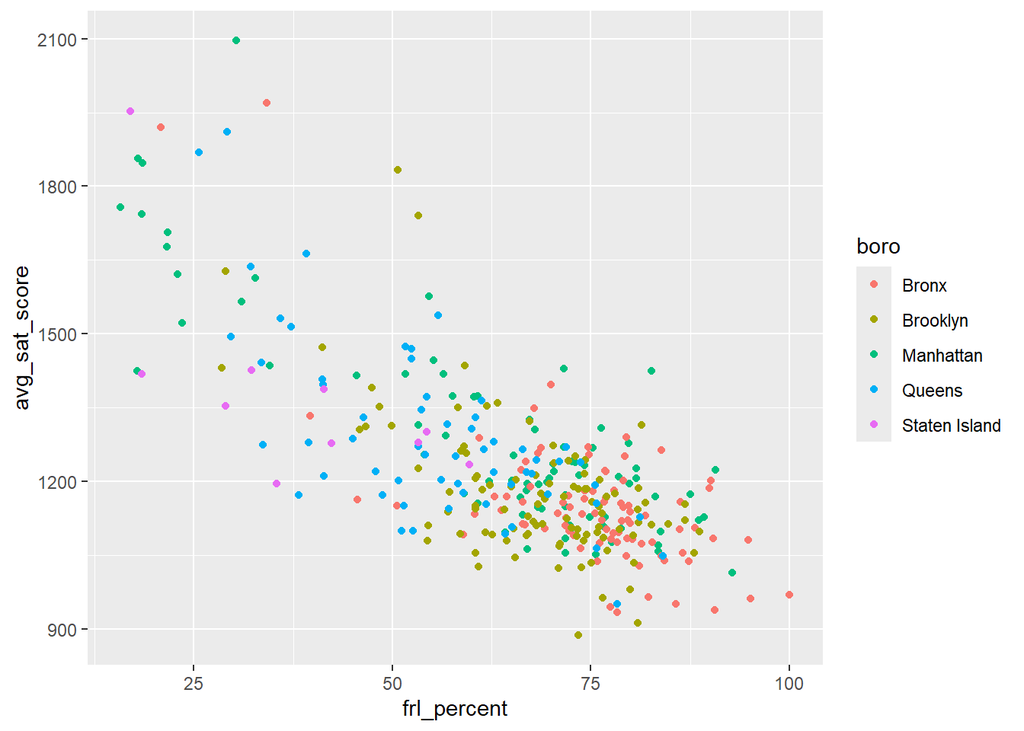

```r
frl_plot <- combined_all %>%
  filter(!is.na(boro)) %>%
  ggplot(aes(x = frl_percent, y = avg_sat_score, color = boro)) +
  geom_point()

frl_plot
```

I plotted the demographic indicators like asian, white, black and hispanic percentage of each school and the average SAT score. Then split it by the borough that each school is from. There was an interesting group of schools in the Bronx that had higher scores than the rest of the schools in the Bronx. I would like to know if those schools had testing programs.

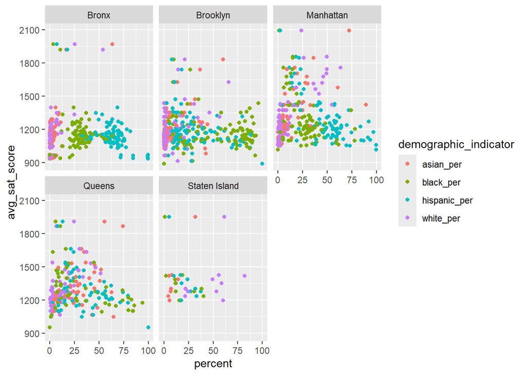

```r
combined_demo_longer <- combined_all %>%
  filter(!is.na(boro)) %>%
  pivot_longer(cols = c(asian_per, white_per, black_per, hispanic_per),
               names_to = "demographic_indicator",
               values_to = "percent")
ggplot(data = combined_demo_longer,
       aes(x = percent, y = avg_sat_score, color = demographic_indicator)) +
  geom_point() + facet_wrap(vars(boro))
```

### Differences in Student, Parent, and Teacher Perceptions

```r
#trying to separate the different response types like students, teachers and the metrics like academic, safety
library(stringr)

persp_longer <- combined_all %>%
    pivot_longer(cols = c(saf_p_11:aca_s_11), #first pivot the columns into survey question
                 names_to = "survey_question",
                 values_to = "score") %>%
  mutate(response_type =                      #next mutate two columns response type ande metric
           if_else((str_sub(survey_question, 4, 6)) == "_p_", "parent",                               if_else((str_sub(survey_question, 4, 6)) == "_t_", "teacher",                             if_else((str_sub(survey_question, 4, 6)) == "_s_", "student", "tot")))) %>%
  mutate(metric =
           if_else((str_sub(survey_question, 1, 3)) == "saf", "saftey and respect",
             if_else((str_sub(survey_question, 1, 3)) == "eng", "engagement",
               if_else((str_sub(survey_question, 1, 3)) == "com", "communication", "academic expectations"))))
```

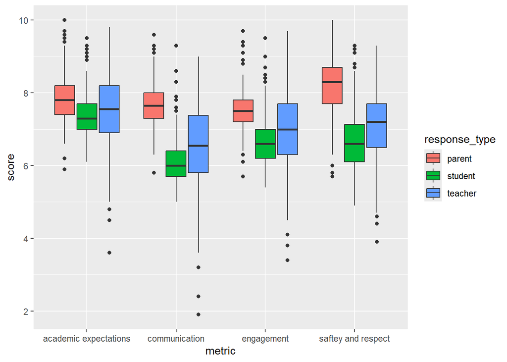

```r
persp_longer %>%
    filter(!response_type == "tot") %>%
    ggplot(aes(x = metric, y = score, fill = response_type)) +
    geom_boxplot() #+
```

```r
  #theme(axis.text.x = element_text(angle = 45, hjust = 1, vjust = 1))
```